# Usage dynamics of the Bike-Sharing System of San Francisco Bay Area

## by Affonso Ciekalski

## Investigation Overview

> This investigation aimed at undertanding how the usage of the bike-sharing system varies along the week. The main focus will be on the variance between weekdays and weekends, and includes the usage dynamics along the day, as well as the duration of trips and the gender distribution.

## Dataset Overview

> This dataset presents just over 180k trips registered with 15 features that include information on the trips and on the users.

## Gender Distribution Among Users

Trips made by people identifying themselves as Male comprise around 75% of the total as shown in the pie chart. This gender gap will be the object of further visualizations.

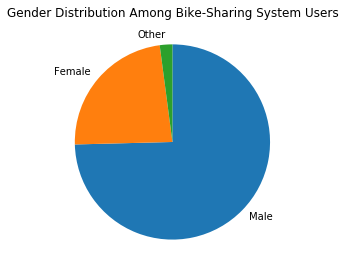

## Distribution of the Duration of the Trips

> When plotting on a log-scale, the duration distribution looks unimodal with the peak at 10 minutes. Most of the trips last from 4 to 20 minutes.

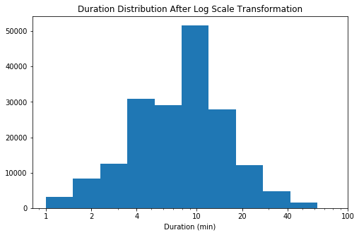

## Hourly Number of Trips vs. Days of the Week

On weekdays, the usage presents two peaks related to the time people go to work and the time they go back home. They happen at around 8 (a.m.) and around 17 (5 p.m.).

Looking at the red line representing the weekends mean, it is possible to notice that the bike-sharing dynamic is different on weekends. The peak happens at 13/14 (1/2 p.m.) with high levels of people using the system from 10 (a.m.) to 18 (6 p.m.).

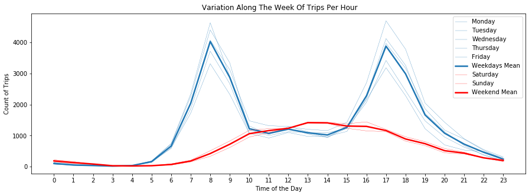

## Duration of the Trips Along the Week for Each Gender

The point plot clearly shows that trips tend to be longer on weekends. Furthermore, trips made by Male individuals are shorter than those made by the other genders in all days of the week. One possible explanation for this difference might be the feeling of insecurity on the streets that make women less prone to cycle, in other words, women might be more careful to ride a bike than men, resulting in longer trips.

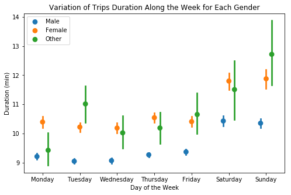

## Duration of the Trips Along the Day for Each Gender

The scarcity of data points from 23 (11 p.m.) to 5 (a.m.) makes it difficult to visualize patterns in this period.

On the other hand, there is a clear pattern in the period starting at 6 (a.m.) till 22 (10 p.m.). Here we notice, one more time, that trips made by Male individuals are shorter than those made by the other genders. In addition, for all genders, trips seem to be shorter in the morning (from 6 to 9 a.m.) and at night and longer around noon.

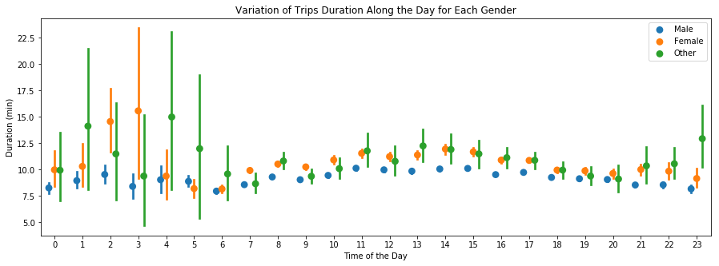

## Gender Distribution on Thursdays and on Saturdays Along the Day

I decided to use trips made on Thursdays to represent weekdays as this is the busiest day of the week, and those made on Saturdays to represent weekends.

It seems that the gender distribution is quite constant on weekdays following the pattern of two peaks representing the home-work-home routine. The same does not hold true for weekends, when the bike-sharing system is busier in the late morning and in the afternoon.

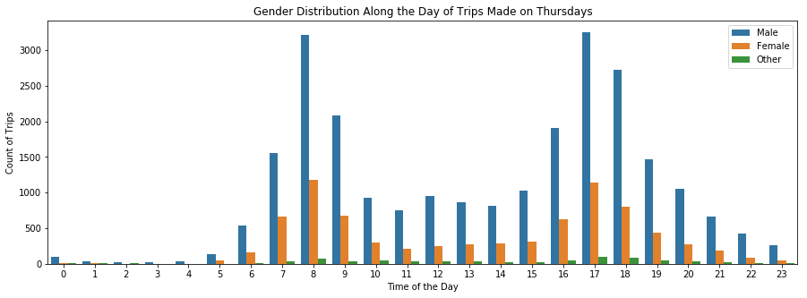

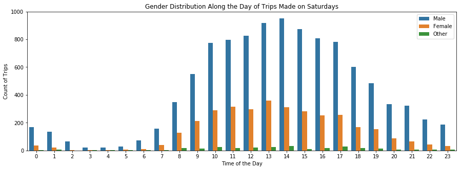